# Computational Practical 1 – Example Report

Matthew Aldridge

MATH2750 Introduction to Markov Processes (2019–20)

*The following is an example report answering the questions on the Computational Practical 1 problem sheet. You can view the original problem sheet [in HTML format](https://mpaldridge.github.io/math2750/C1.html) or [as an Rmd file](https://mpaldridge.github.io/math2750/C1.Rmd).*

**Question 1.** *We will be studying the simple random walk starting from $X_0 = 0$ with up probability $p = 0.6$ and down probability $q = 1 - p = 0.4$. Produce a sample of the first $N = 10$ steps of this simple random walk.*

First we use the `sample` function to produce the increments process – a vector of $N$ independent values that are $+1$ with probability $p = 0.6$ and $-1$ with probability $q = 1 - p = 0.4$.

```r
p <- 0.6
q <- 1 - p
N <- 10
Z <- sample(c(1, -1), N, replace = TRUE, prob = c(p, q))
Z
```

```
##  [1] -1  1  1  1  1  1 -1  1  1 -1
```

We use `replace = TRUE` as we are repeatedly *sampling with replacement* from the set $\{+1, -1\}$; that is, each increment is a new *independent* sample that can be either $+1$ or $-1$.

We then form the random walk as the cumulative sums of the increments process.

```r
X <- cumsum(Z)
X
```

```
##  [1] -1  0  1  2  3  4  3  4  5  4
```

If needed, we can add the starting point $X_0 = 0$ with

```r
c(0, X)
```

```
##  [1]  0 -1  0  1  2  3  4  3  4  5  4
```

**Question 2.** *Plot a sample of the random walk for $N = 10$ steps and for $N = 10000$ steps. Try to make your plot look smart, for example by giving it a title and labelling the axes. Briefly comment on the plots.*

For $N = 10$, we plot the random walk with

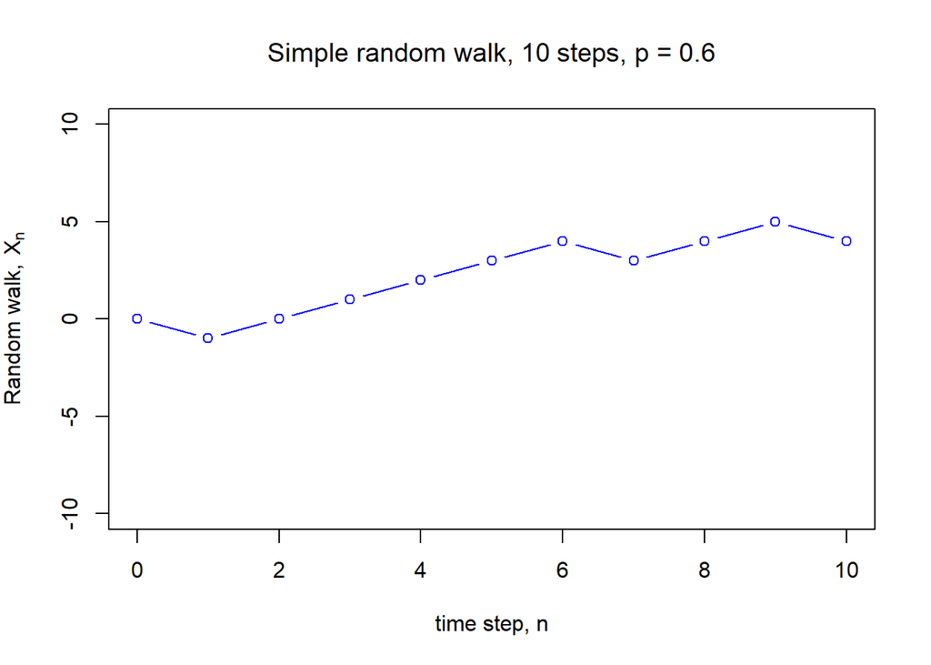

```r
plot(0:N, c(0, X),
     type = "b",
     col  = "blue",
     xlab = "time step, n",
     ylim = c(-N, N),
     # The following `bquote` syntax allows some fancy titling
     # but is an optional extra
     ylab = bquote("Random walk, " ~ X[n]),
     main = bquote("Simple random walk," ~ .(N) ~ "steps, p =" ~ .(p)))
```

Here, `type = "b"` means we plot **both** points and lines. By plotting `c(0, X)` against `0:N` ${}= (0,1,\dots, N)$, we ensure our plot also includes the starting point $X_0 = 0$ of the random walk.

We see that the random walk takes steps up $1$ and down $1$ roughly equally, although slightly more likely to be up on average. There is (usually) quite a lot of variation, in that the walk often goes up then down rather than a regular drift upwards.

We can repeat this for $N = 10000$.

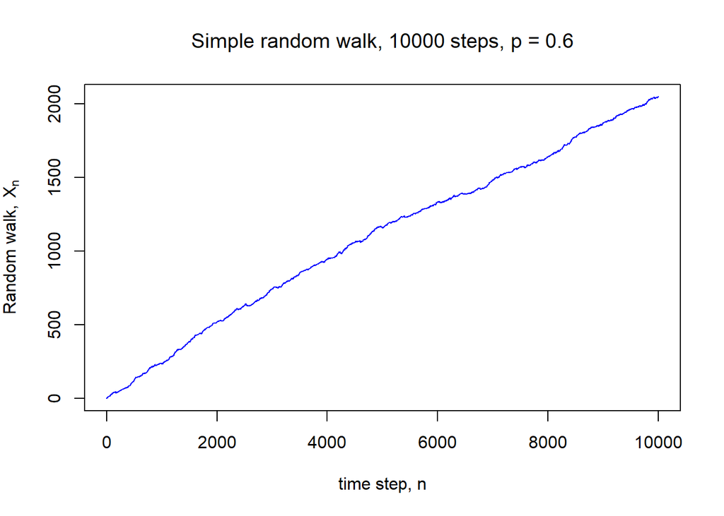

```r
N <- 10000
Z <- sample(c(1, -1), N, replace = TRUE, prob = c(p, q))
X <- cumsum(Z)
plot(0:N, c(0, X),
     type = "l",
     col  = "blue",
     xlab = "time step, n",
     ylab = bquote("Random walk, " ~ X[n]),
     main = bquote("Simple random walk," ~ .(N) ~ "steps, p =" ~ .(p)))
```

Here, `type = "l"` just gives **lines**, which is easier to read when there are many datapoints. By not providing `xlim` or `ylim`, we allowed R to pick the most appropriate axis limits for itself.

We see that the main drift of the random walk is steadily upwards, although there are some small variations within the linear drift. This is because the standard deviation is $\sqrt{4pqn}$, which scales like $\sqrt{n}$, while the drift is $(p-q)n$, which scales like $n$ (for $p \neq 1/2$). So as the number of steps gets larger, the drift becomes much more important than the variation, and the curve looks increasingly like a straight line.

**Question 3.** *Make a function in R that produces a sample of a simple random walk for given $p$ of length $N$. Test your function to check it works. What are the advantages of making a a function like this?*

We used two functions. First, the “random plus-or-minus” function `rpm` gives $N$ random $\pm 1$s.

```r
rpm <- function(N, p) {
  q <- 1 - p
  sample(c(1, -1), N, replace = TRUE, prob = c(p, q))
}
```

Second, we use `rpm` in our function for the random walk itself.

```r
RandomWalk <- function(N, p) {
  Z <- rpm(N, p)
  cumsum(Z)
}
```

We can also make a function to plot a random walk.

```r
PlotRandomWalk <- function(N, p, type = "l") {
  X <- RandomWalk(N, p)
  plot(0:N, c(0, X),
       type = type,
       col  = "blue",
       xlab = "time step, n",
       ylab = bquote("Random walk, " ~ X[n]),
       main = bquote("Simple random walk," ~ .(N) ~ "steps, p =" ~ .(p)))
}
```

This has the advantage that we can now very quickly produce and plot random walks without writing (or copying-and-pasting) many new lines of code each time.

We can test it works by producing a simple random walk of length $50$ with $p = 0.3$.

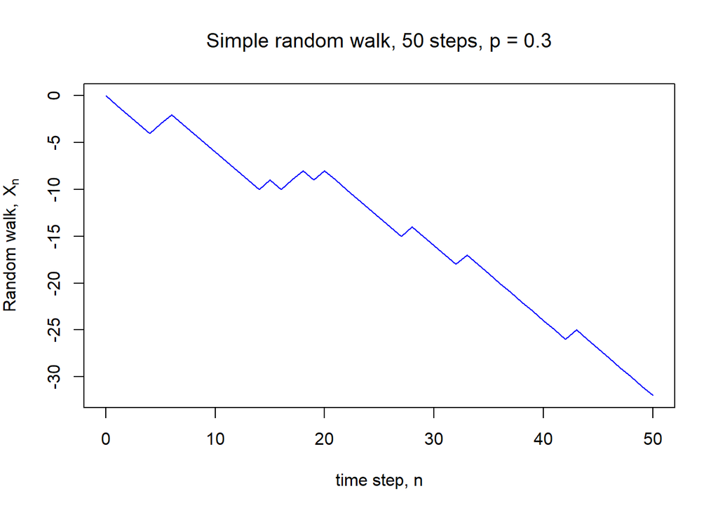

```r
PlotRandomWalk(50, 0.3)
```

**Question 4.** *Estimate the expected value of of the simple random walk at $N = 100$ steps by simulating many random walks and taking an average. How does this compare with the true answer?*

We use the `replicate` function to get $10000$ samples of the random walk, and print the mean value of $X_{100}$.

```r
N <- 100
trials <- 10000
samples <- replicate(trials, RandomWalk(N, p)[N])
mean(samples)
```

```
## [1] 19.9718
```

We know that the true expectation is
$$\mathbb{E}X_{100} = 100(p-q) = 100(0.6 - 0.4) = 20 .$$

This simulated value of $19.9718$ is very close to the true value of $20$.

**Question 5.** (Optional) *Investigate estimating other properties of the simple random walk through simulation.*

Some things we could investigate include:

- variance or standard deviation of the random walk;
- $\mathbb P(a \leq X_n \leq b)$ for some approriate $a < b$, and comparing with a normal approximation;
- ruin probability or expected duration for the gambler’s ruin.

Here, we’ll try investigating the ruin probability of a gambler’s ruin problem. (This is the most complicated of the three suggestions above.)

First we have a function that simulates a gambler’s ruin process, and outputs whether or not Alice ruins. This uses our `rpm` function from Question 3.

```r
GamblersRuin <- function(p, a, m) {
  alice_money <- a  # Alice starts with £a

  while (alice_money > 0 && alice_money < m) {  # until the game finishes...
    alice_money <- alice_money + rpm(1, p)      # ...play another round
  }

  if (alice_money == 0) {
    return(1)  # returns 1 if Alice ruins
  } else {
    return(0)  # returns 0 if Bob ruins
  }
}
```

We can test this with a gambler’s ruin problem where Alice starts with £$a$ = £2, and Bob starts with £3, so the total pot is $m = 2 + 3 = 5$. Let’s say Alice wins each round with probability $p = 0.4$.

```r
p <- 0.4
a <- 2
m <- 5

trials <- 10000
GRsamples <- replicate(trials, GamblersRuin(p, a, m))
mean(GRsamples)  # estimated ruin probability
```

```
## [1] 0.8048
```

We can compare this simulated answer $0.8048$ to the true ruin probability given by
$$r_a = \frac{\rho^a - \rho^m}{1 - \rho^m} ,$$
where $\rho = q/p$. We can calculate this in R.

```r
TrueRuinProb <- function(p, a, m) {
  q   <- 1 - p
  rho <- q / p
  (rho^a - rho^m) / (1 - rho^m)
}

TrueRuinProb(p, a, m)
```

```
## [1] 0.8104265
```

This formula gives the answer $r_a = 0.8104$, which is close to the simulated answer $0.8048$.

### Note on this report

This example report was written using **[R Markdown](https://rmarkdown.rstudio.com/lesson-1.html)**, which allows the easy integration of text, LaTeX, displayed R code, and executed R code in one document. Upsides of using R Markdown include that it’s a convenient way to turn some R code into a documented report, and that the output looks professional. Downsides include that it’s another thing to learn, and that it rarely works properly on University computers. If you’d like to try, I recommend reading [Using R Markdown for Class Reports](https://www.stat.cmu.edu/~cshalizi/rmarkdown/) by Cosma Shalizi.

You can download the [R Markdown source code for this report here](https://mpaldridge.github.io/math2750/C1-sols.Rmd). If you open that file in RStudio and click on `knit`, it should produce [the HTML version of the report](https://mpaldridge.github.io/math2750/C1-sols.html) – although it probably won’t work on a University computer. Note also that the R code (including generation of random numbers) is run anew, so your graphs and sample estimates will not be exactly the same as mine.